# FM project

2023-04-25

Reads

https://www.eia.gov/todayinenergy/detail.php?id=55920#:~:text=Europe%20became%20the%20primary%20destination,U.S.%20LNG%20exports%20to%20Europe.

## Analysing U.S. energy exports

### 1.Introduction

Energy commodities play a pivotal role in the global economy, as they are essential for economic growth and development. They are required for transportation, manufacturing, heating, cooling, and many other critical activities that drive economic activity.

The production, consumption, and trade of energy commodities have significant impacts on the global economy. The prices of energy commodities are influenced by supply and demand factors, geopolitical tensions, weather events, and technological advances.

The recent COVID-19 pandemic and the war in Ukraine have created unprecedented changes in the energy market, and understanding the impact of these events is crucial for policymakers, analysts, and investors. This study aims to examine how the Russian war on Ukraine affected energy exports of the United States to the OECD Europe countries.

OECD Europe was selected as the region, as because of geographical and historical relations it was most influenced region by the Russian war on Ukraine. The United States has been chosen as the focus because it is one of the leading producers and exporters of energy commodities, and its export trends have significant implications for the global energy market. Moreover, the United States serves as a significant alternative for OECD Europe countries to turn to after the imposition of sanctions on Russia.

In this study, we will analyze the impact of the war in Ukraine on US energy exports to OECD Europe. Specifically, we will focus on three main energy products: crude oil, petroleum products, and natural gas. By examining trends in these exports, we can better understand how the geopolitical events in Ukraine have affected the energy market in Europe. Additionally, we will investigate changes in OECD Europe’s dependence on Russian gas to see how energy dynamics in the region have shifted.

### 2. Time Series Graphics

#### 2.1 Dataset

The data sets utilized in this study consist of monthly observations of Country’s reliance on Russian oil products, USA’s natural gas exports by country, USA’s total crude oil exports by destination, and USA’s petroleum products exports by destination.

Our primary source of data is the U.S. Energy Information Administration (EIA), an independent organization that collects, analyzes, and disseminates data and information related to energy production, consumption, and distribution in the United States. Also, for the purpose of this study we are using data from the International Energy Agency (IEA), which is an intergovernmental organization that was established in 1974 to promote global cooperation on energy issues.

In case of data on reliance on Russian Oil the dataset contains monthly total oil imports from Russia as a percentage of total oil imports for a selected group of European countries belonging to the Organization for Economic Co-operation and Development (OECD) from January 1990 to October 2022. The dataset includes the date, country name, and the percentage of total oil imports that came from Russia for each observation.

In this section, we will analyze three datasets that pertain to US exports of Crude oil, Petroleum Products, and Natural Gas, all measured in barrels. Prior to converting the data to tsibble format, we performed data cleaning and formatting. To simplify the data, we converted each dataset to have the same structure, with three columns: date, destination country, and the amount exported. After standardizing the format, we converted each dataset to tsibble format. We then filtered the data to only include countries that are part of the OECD and summarized the results based on the amount exported on each date, removing country names and leaving only the date and amount exported. Finally, we merged all three tsibble tables into one by using the left join function and pivoting the data, resulting in a final time series that represents US exports of the three different products in barrels to OECD countries. The tsibble contains three columns: Date, Export Type, and Amount.

[figure not shown]

#### Including Plots

The graph below reveals significant growth in Crude oil and Natural gas exports since around 2015, with a clear year-on-year increase in both goods, indicating a noticeable trend. Moreover, it appears that the time series for these two products are non-stationary, possibly suggesting the presence of a trend, seasonality, or both. In 2022/2023, Crude oil and Natural gas exports reached their peak, with crude oil almost 60,000 and natural gas around 40,000. Conversely, the time series for Petroleum products appears to be stationary, with a slight increasing trend that may require further analysis.

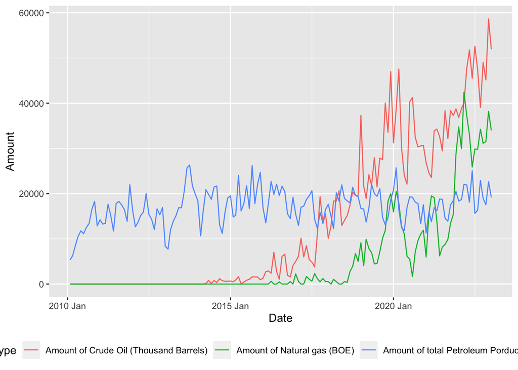

```r
total_exp_oecd %>% ggplot(
 aes(Date,Amount,color = `Export Type`)) +
   geom_line()+
   labs(x = "Date", y = "Amount")+
  theme(legend.position = "bottom")
```

Looking at natural gas exports, we can see that the US did not export to OECD countries until after 2016, when low amounts of natural gas were first exported. In 2018, exports increased significantly, reaching their first peak in 2020. We can see a similar positive trend and possible seasonality as in the crude oil graph. During the COVID-19 pandemic, exports decreased significantly, but again, after the Russian invasion, exports increased significantly, reaching 40,000 barrels. This suggests that OECD countries stopped buying natural gas from Russia.

Finally, looking at petroleum product exports, we can see some fluctuations since 2010, but no clear trend. Seasonality may exist. The changes during COVID-19 and after the Russian invasion were not as significant as in the other two graphs.

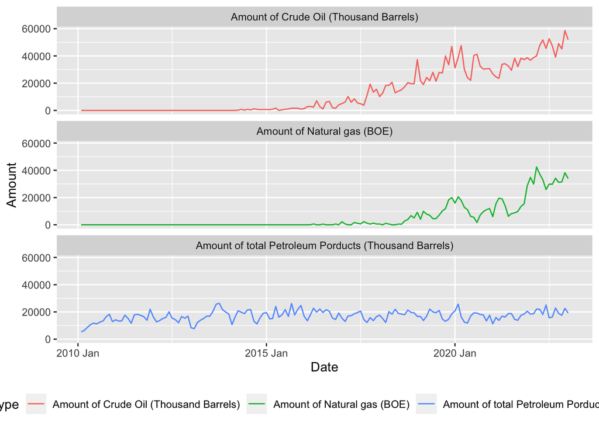

```r
total_exp_oecd %>%
  ggplot(aes(Date, Amount, color = `Export Type`)) +
  geom_line()+
  labs(x = "Date", y = "Amount")+
  theme(legend.position = "bottom") +
  facet_wrap(~`Export Type`, ncol = 1)
```

#### 2.3 Time Series Patterns

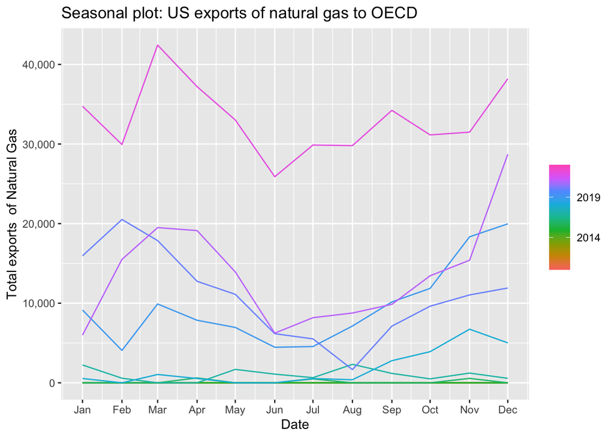

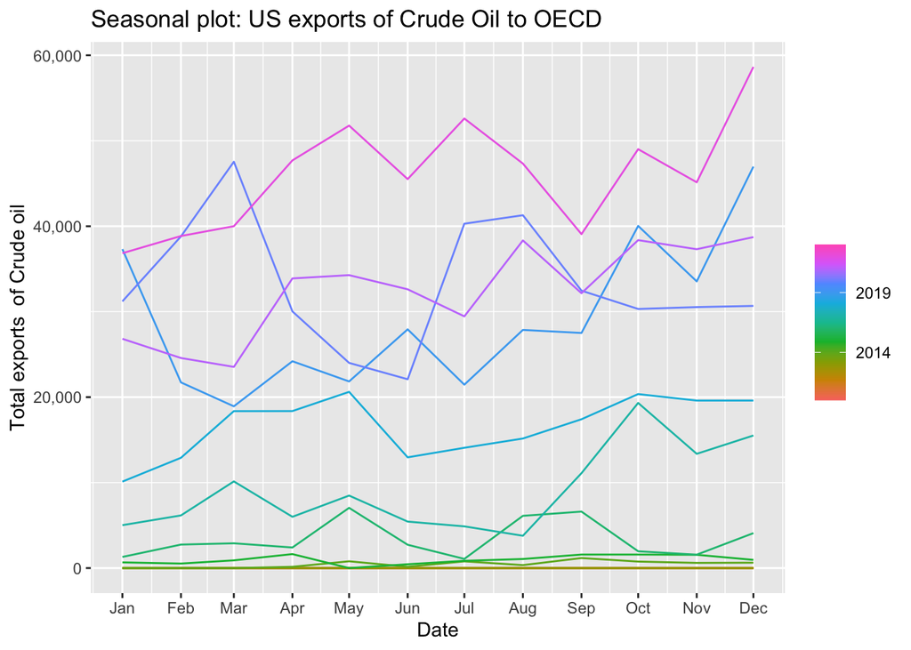

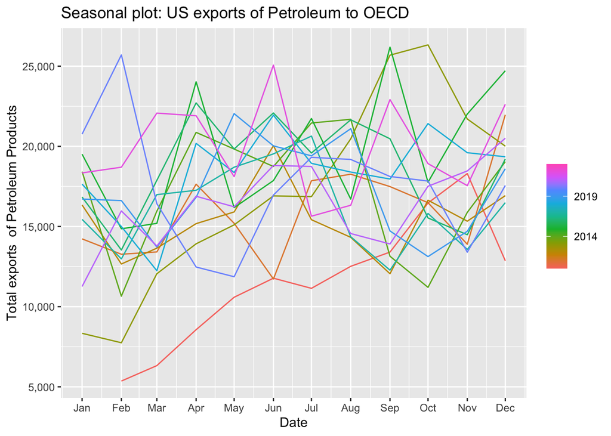

To further elaborate, the data analysis of US exports of oil products to OECD shows that seasonal patterns can differ depending on the type of product being exported. While natural gas and crude oil both display some level of seasonality, petroleum products do not show any significant trends.

In the case of natural gas, we can see a clear increase in exports during the colder months, which could be due to increased demand for heating purposes. Conversely, during the warmer months, exports tend to decrease. This pattern is consistent throughout the years, with the exception of some yearly fluctuations.

Regarding crude oil, the seasonal pattern is not as clear as with natural gas. However, we still observe a similar trend where exports tend to increase during the colder months and decrease during the warmer months. Interestingly, we see a deviation from this pattern in 2022, with exports remaining high even during spring and summer months. This could be attributed to the political tensions caused by the Russian invasion in Ukraine.

On the other hand, the export of petroleum products does not appear to have any notable seasonal patterns. While there may be a slight increase towards the end of each year, there is no clear trend observed year-over-year.

Overall, analyzing seasonal patterns in the US export of oil products can provide insights into demand patterns and other underlying factors that affect the global oil market.

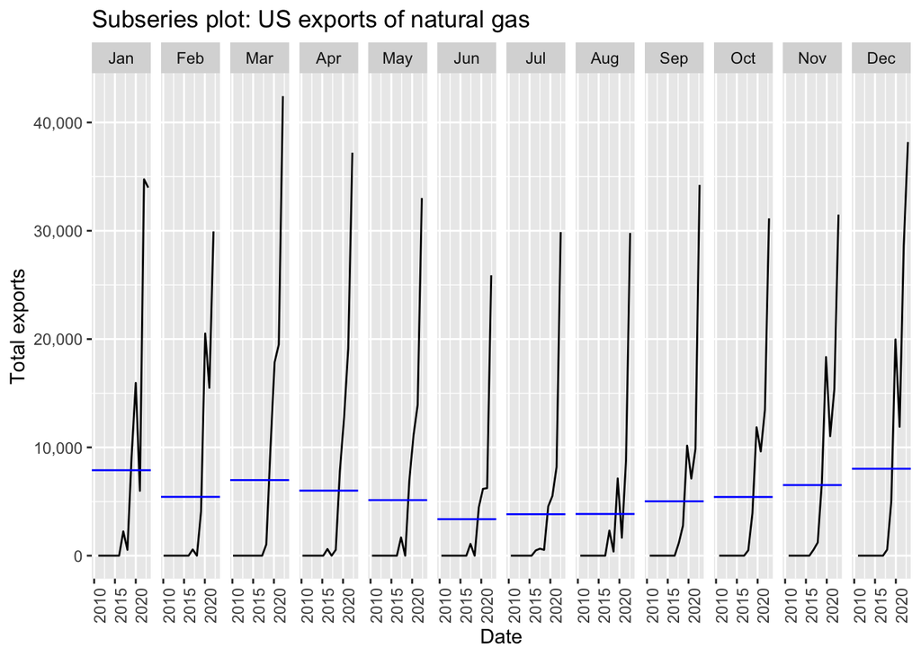

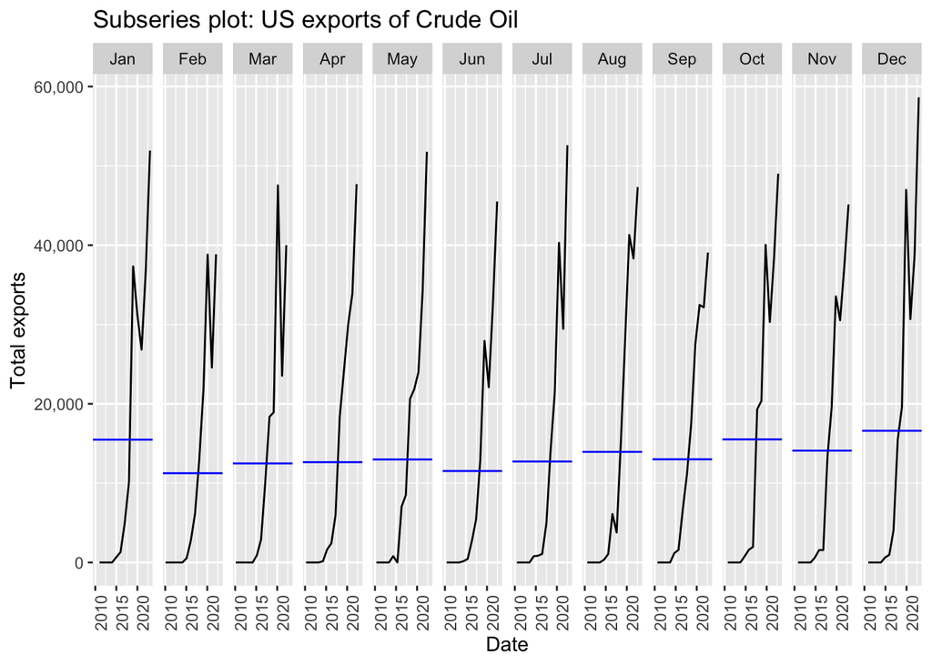

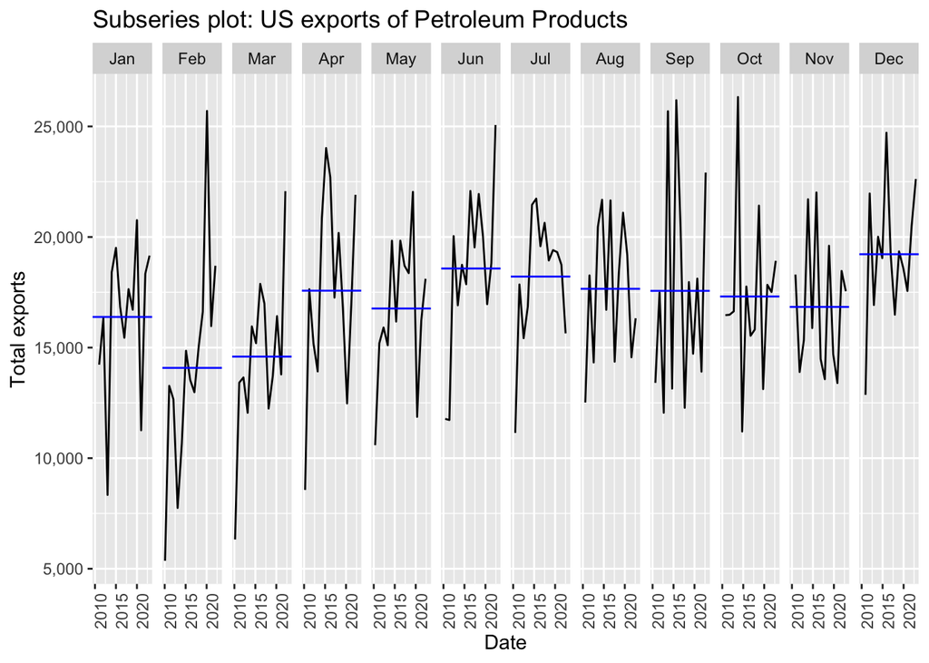

To gain a better understanding of seasonality, we created additional plots known as subseries seasonal plots. These graphs provide a clearer view of monthly exports and also display the means over each month for the analyzed time series period.

```
## Response variable not specified, automatically selected `var = Total_Exports`
```

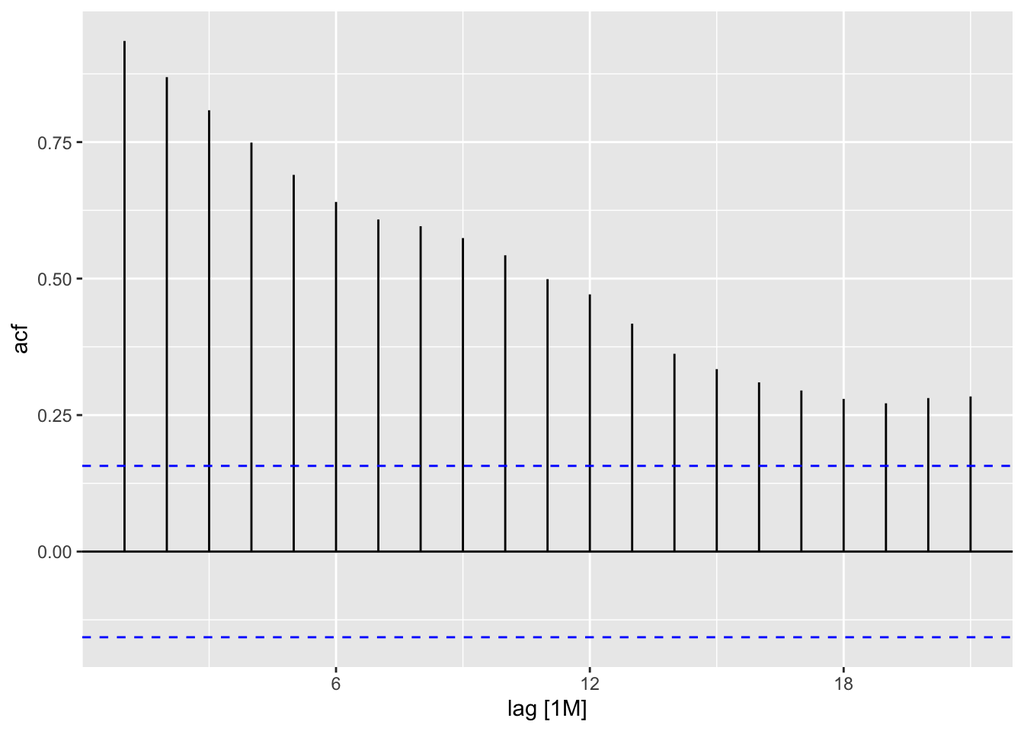

```
## Response variable not specified, automatically selected `var = Total_Exports`
```

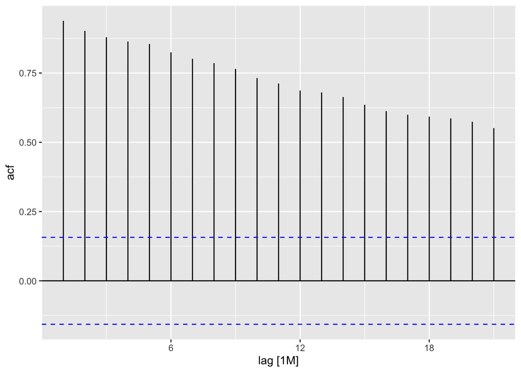

```
## Response variable not specified, automatically selected `var = Total_Exports`
```

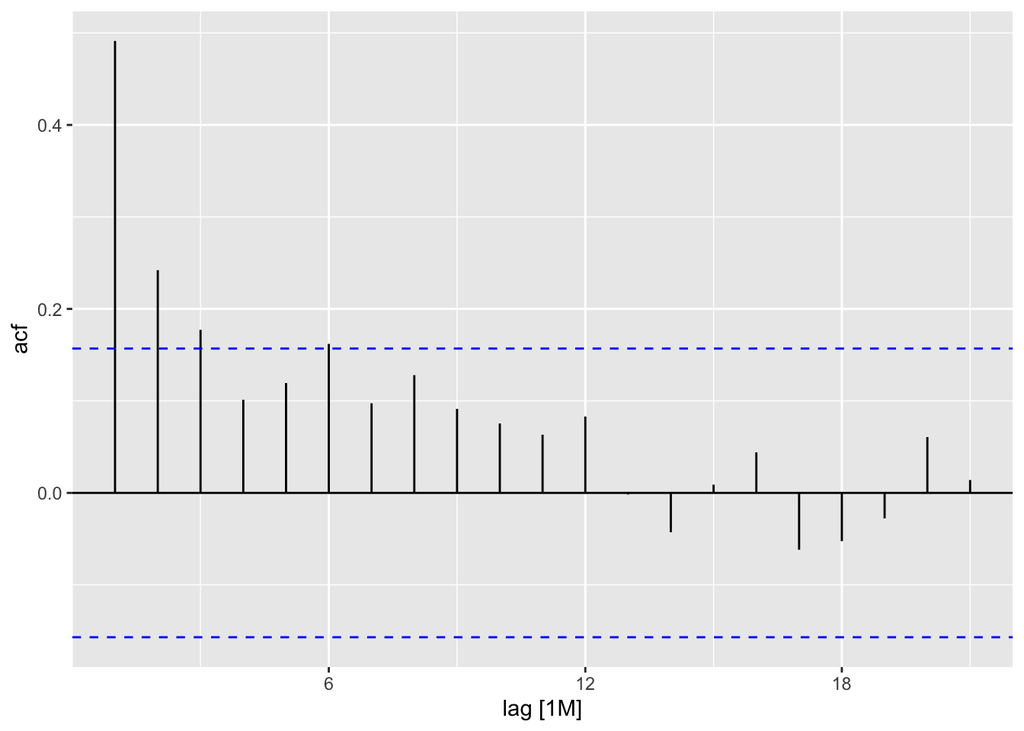

The autocorrelation function (ACF) plot displays the correlation between a time series and its own lagged values. A high ACF value for a particular lag indicates that the current values of the time series are significantly correlated with the past values at that lag.

The ACF plot for US exports of Petroleum Products to OECD indicates that there is no noticeable seasonality in the time series. The first three lags show significant positive correlations, suggesting some short-term dependence between current exports and those from 1 to 3 months ago. However, beyond the third lag, the ACF values fall within the confidence interval, indicating a weakening of the correlation. This suggests that there is no clear and consistent pattern of seasonality in the exports of petroleum products.

Finally, based on the ACF plots of the US exports of natural gas, crude oil, and petroleum products to OECD, we can conclude that the time series do not appear to be white noise.

### 3. Time series decomposition

#### 3.1. Adjustments

After a thorough review of the data, we determined that no adjustments were necessary. We did not observe any calendar or population effects on the monthly exports data, and the exports data is already presented in barrels or barrels of oil equivalent (BOE), so no inflation adjustments were required.

#### 3.2. Transformations

Given the nature of the three data sets that are being used: Crude Oil Exports, Petroleum exports and Natural gas exports we decided that certain transformations might be necessary for further analysis. Not normal distribution of the data and differing variance were seen as potential threat for correct conclusions. We identified Box-Cox transformation as necessary to continue since it stabilizes the variance of the data and makes the distribution more normal. This will improve the reliability of the statistical tests and provide more accurate results.

For Box-Cox transformation to be performed we found lambda for each time series and than use it to transform the time series.

#### 3.3. Decomposition

```
## # A dable: 156 x 7 [1M]
## # Key:     .model [1]
## # :        Amount of Crude Oil (Thousand Barrels) = trend + season_year +
## #   remainder
##    .model     Date Amount of Crude Oil (Thousan…¹  trend seaso…² remai…³ seaso…⁴
##    <chr>     <mth>                          <dbl>  <dbl>   <dbl>   <dbl>   <dbl>
##  1 stl    2010 Feb                              0 -20.8    -31.4    52.2    31.4
##  2 stl    2010 Mar                              0 -18.7    222.   -203.   -222.
##  3 stl    2010 Apr                              0 -16.6     41.9   -25.3   -41.9
##  4 stl    2010 May                              0 -14.4    383.   -369.   -383.
##  5 stl    2010 Jun                              0 -13.1   -326.    339.    326.
##  6 stl    2010 Jul                              0 -11.9   -435.    447.    435.
##  7 stl    2010 Aug                              0 -10.6   -175.    186.    175.
##  8 stl    2010 Sep                              0  -7.52   300.   -293.   -300.
##  9 stl    2010 Oct                              0  -4.45   258.   -254.   -258.
## 10 stl    2010 Nov                              0  -1.39  -196.    197.    196.
## # … with 146 more rows, and abbreviated variable names
## #   ¹`Amount of Crude Oil (Thousand Barrels)`, ²season_year, ³remainder,
## #   ⁴season_adjust
```

```
## # A dable: 156 x 7 [1M]
## # Key:     .model [1]
## # :        Amount of total Petroleum Porducts (Thousand Barrels) = trend +
## #   season_year + remainder
##    .model     Date Amount of total Petroleum Po…¹  trend seaso…² remai…³ seaso…⁴
##    <chr>     <mth>                          <dbl>  <dbl>   <dbl>   <dbl>   <dbl>
##  1 stl    2010 Feb                           5360  8579.  -4551.   1332.   9911.
##  2 stl    2010 Mar                           6323  9169.  -2557.   -290.   8880.
##  3 stl    2010 Apr                           8564  9759.    954.  -2150.   7610.
##  4 stl    2010 May                          10587 10349.   -116.    354.  10703.
##  5 stl    2010 Jun                          11776 10911.    618.    247.  11158.
##  6 stl    2010 Jul                          11143 11472.   1216.  -1544.   9927.
##  7 stl    2010 Aug                          12516 12033.   1104.   -621.  11412.
##  8 stl    2010 Sep                          13405 12570.   1109.   -274.  12296.
##  9 stl    2010 Oct                          16466 13107.    822.   2537.  15644.
## 10 stl    2010 Nov                          18301 13644.    567.   4090.  17734.
## # … with 146 more rows, and abbreviated variable names
## #   ¹`Amount of total Petroleum Porducts (Thousand Barrels)`, ²season_year,
## #   ³remainder, ⁴season_adjust
```

```
## # A dable: 156 x 7 [1M]
## # Key:     .model [1]
## # :        Amount of Natural gas (BOE) = trend + season_year + remainder
##    .model     Date `Amount of Natural gas (BOE)` trend season…¹ remain…² seaso…³
##    <chr>     <mth>                         <dbl> <dbl>    <dbl>    <dbl>   <dbl>
##  1 stl    2010 Feb                             0 38.2    -39.0     0.829   39.0
##  2 stl    2010 Mar                             0 33.2    -39.4     6.19    39.4
##  3 stl    2010 Apr                             0 28.2    -20.1    -8.17    20.1
##  4 stl    2010 May                             0 23.2    -16.4    -6.87    16.4
##  5 stl    2010 Jun                             0 19.2    -59.8    40.7     59.8
##  6 stl    2010 Jul                             0 15.1    -40.8    25.7     40.8
##  7 stl    2010 Aug                             0 11.0     -6.19   -4.78     6.19
##  8 stl    2010 Sep                             0  7.98   -14.1     6.07    14.1
##  9 stl    2010 Oct                             0  4.99   -29.0    24.0     29.0
## 10 stl    2010 Nov                             0  2.01   108.   -110.    -108.
## # … with 146 more rows, and abbreviated variable names ¹season_year,
## #   ²remainder, ³season_adjust
```

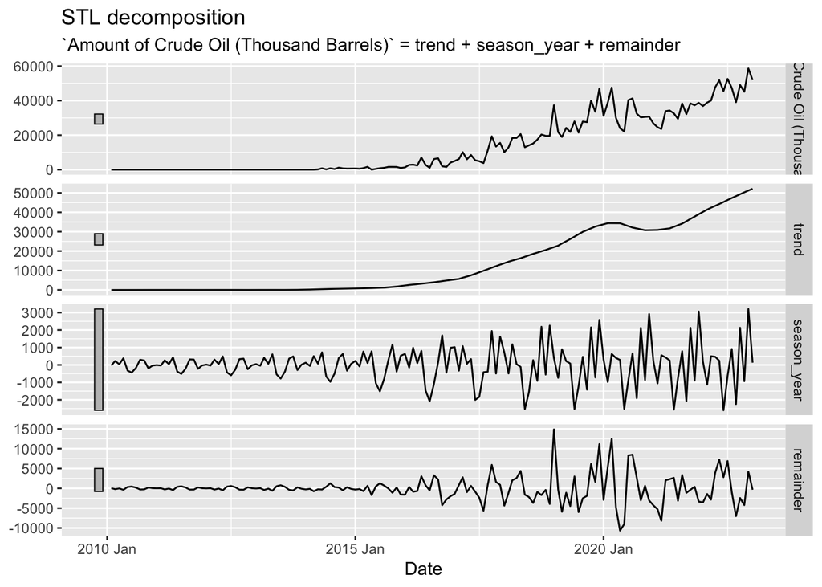

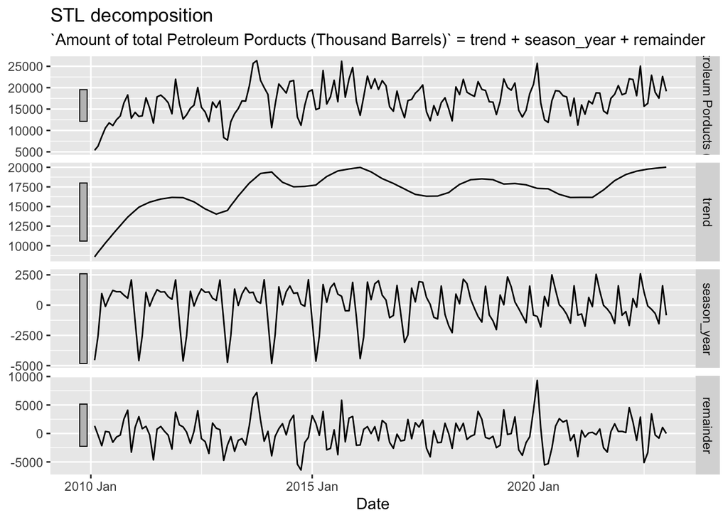

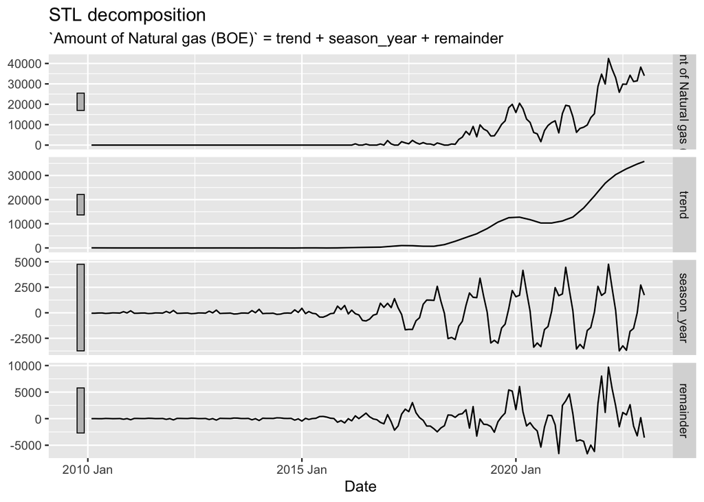

There are several conclusions to be drawn looking at the STL decomposition. First of all, we can see clear trend in exports of crude oil and natural gas while petroleum products does not have clear trend. In both cases of exports of crude oil and natural gas we can clearly see slight drops in exports after 2020 which can be explained by COVID 19 pandemic and continued growths after situation normalized. Another observation worth mentioning is the fact that exports of two mentioned products hits all time high around the year 2022. This can be explained by huge declines of both products from Russia after sanction were imposed.

Moreover, we can see seasonality in exports of all three products.That is no surprise, given that all energy products are highly reactive to different seasons.

After decomposing the data of all three time series and looking at each components separately we decided that exports of petroleum products will not be analysed further. Exports of petroleum products to OECD Europe markets does not have clear trend therefore indicating that Russian invasion in Ukraine did not have positive effect on growing imports from US. This can be explained by the fact that embargo on refined oil products from EU 27 was introduced as of 5 February 2023. Therefore, Russian war on Ukraine and sanctions on Russia that followed did not have any visible effect on US exports of petroleum products to OECD Europe markets.

## 4. The forecaster’s toolbox

#### 4.1. Exploring different simple forecasting methods

Before moving forward with forecasting using simple forecasting methods we take a look at both time series and what simple forecasting methods works best with both

```
## # A tibble: 4 × 14
##   .model...1 .type...2 RMSE...3 MAE...4 MAPE...5 MASE.…¹ RMSSE…² .mode…³ .type…⁴
##   <chr>      <chr>        <dbl>   <dbl>    <dbl>   <dbl>   <dbl> <chr>   <chr>
## 1 Drift      Training      5.72    4.38     10.1   0.472   0.517 Drift   Traini…
## 2 Mean       Training     15.4    13.3      36.1   1.44    1.39  Mean    Traini…
## 3 Naive      Training      5.76    4.36     10.0   0.470   0.520 Naive   Traini…
## 4 SNaive     Training     11.1     9.28     18.3   1       1     SNaive  Traini…
## # … with 5 more variables: RMSE...10 <dbl>, MAE...11 <dbl>, MAPE...12 <dbl>,
## #   MASE...13 <dbl>, RMSSE...14 <dbl>, and abbreviated variable names
## #   ¹MASE...6, ²RMSSE...7, ³.model...8, ⁴.type...9
```

We begin with evaluating each method performance on given time series using function accuracy() and then plot each method against train data to see visually see how each method performs.

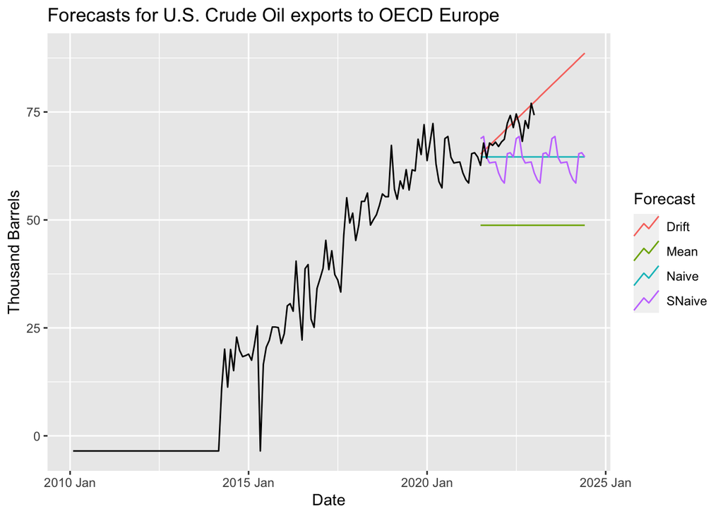

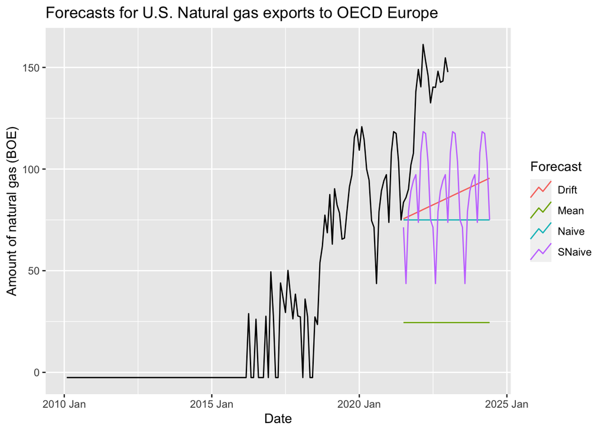